# Accuracy in facial trustworthiness impressions: Kernel of truth or modern physiognomy. A meta-analysis. Rater-level analysis

Electronic Supplementary Material

omitted for blind review

17 November 2020

```r
# to install orchaRd pacakge

# install.packages('devtools') install.packages('tidyverse')
# install.packages('metafor') install.packages('patchwork')
# install.packages('R.rsp')

# devtools::install_github('itchyshin/orchard_plot', subdir = 'orchaRd',
# force = TRUE, build_vignettes = TRUE) Load required packages.

library(tidyverse)  #Tidy family and related packages
library(metafor)  #Meta-analysis package
library(MCMCglmm)  #Bayesian mixed model package
library(MuMIn)  #Model selection and averaging package
library(viridis)  #Nice colours
library(kableExtra)  #For making nice tables
library(psych)  #Certain calculations
library(matrixcalc)  #For generating variance covariance matrices
library(Matrix)  #For generating variance covariance matrices
library(orchaRd)  #Functions for I^2 and R^2
library(patchwork)  #For orchaRd package
library(nlme)  #GLS models
```

### Table of the dataset

```r
# Load dataset
data <- read.csv("DataTrustMA.csv", na.strings = "")

# drop any empty rows
data <- data[is.na(data$Ref) == FALSE, ]

# subset to useful data
keepVars <- c("Year", "Paper", "FaceSample", "ParticipantSample", "GTOpRecode",
    "RespMethRecode", "OverallDomain", "PhotoTypeRecode", "Point_of_Decision",
    "UseFirstVersion", "PhotoSource", "UnitOfAnalysis", "N", "N_Stimuli", "final_r")
data <- data[, keepVars]

# subset only the rater-level effects
data <- data[data$UnitOfAnalysis == "Rater", ]

# when we do this, we end up with some retained levels within factors which
# are no longer used. We can get rid of these using droplevels():
data <- droplevels(data)

# examine data
str(data)
```

```
## 'data.frame':    37 obs. of  15 variables:
##  $ Year             : int  2013 2013 2013 2013 2013 2013 2013 2009 2009 2015 ...
##  $ Paper            : Factor w/ 13 levels "Paper10","Paper11",..: 10 10 10 11 11 11 11 12 12 13 ...
##  $ FaceSample       : Factor w/ 17 levels "sample10","sample11",..: 17 17 17 16 16 16 16 16 16 17 ...
##  $ ParticipantSample: Factor w/ 33 levels "sample11","sample12",..: 31 32 33 1 2 3 4 5 6 7 ...
##  $ GTOpRecode       : Factor w/ 2 levels "Behavioural ",..: 1 1 1 1 1 1 1 1 1 1 ...
##  $ RespMethRecode   : Factor w/ 2 levels "Explicit","MoneyTransfer": 2 2 2 1 1 1 1 1 1 2 ...
##  $ OverallDomain    : Factor w/ 6 levels "Aggressiveness",..: 4 4 4 1 1 1 1 1 1 4 ...
##  $ PhotoTypeRecode  : Factor w/ 2 levels "computer","original": 2 2 2 2 2 2 2 2 2 2 ...
##  $ Point_of_Decision: Factor w/ 2 levels "No","Yes": 1 1 1 1 1 1 1 1 1 1 ...
##  $ UseFirstVersion  : int  1 1 1 1 1 1 1 1 1 1 ...
##  $ PhotoSource      : Factor w/ 3 levels "lab","media",..: 1 1 1 1 1 1 1 1 1 1 ...
##  $ UnitOfAnalysis   : Factor w/ 1 level "Rater": 1 1 1 1 1 1 1 1 1 1 ...
##  $ N                : int  208 93 180 56 51 16 16 31 16 86 ...
##  $ N_Stimuli        : int  60 60 60 24 24 24 24 24 24 12 ...
##  $ final_r          : num  0.1106 0.1518 0.0435 0.4952 0.4985 ...
```

```r
names(data)
```

```
##  [1] "Year"              "Paper"             "FaceSample"
##  [4] "ParticipantSample" "GTOpRecode"        "RespMethRecode"
##  [7] "OverallDomain"     "PhotoTypeRecode"   "Point_of_Decision"
## [10] "UseFirstVersion"   "PhotoSource"       "UnitOfAnalysis"
## [13] "N"                 "N_Stimuli"         "final_r"
```

```r
# fisher's z transform r values
data$Zr <- fisherz(data$final_r)

# compute w (weight)
data$w <- data$N - 3

# making a scrollable table
kable(data, "html") %>% kable_styling("striped", position = "left") %>% scroll_box(width = "100%",
    height = "500px")
```

|  | Year | Paper | FaceSample | ParticipantSample | GTOpRecode | RespMethRecode | OverallDomain | PhotoTypeRecode | Point_of_Decision | UseFirstVersion | PhotoSource | UnitOfAnalysis | N | N_Stimuli | final_r | Zr | w |
| --- | --- | --- | --- | --- | --- | --- | --- | --- | --- | --- | --- | --- | --- | --- | --- | --- | --- |
| 2 | 2013 | Paper5 | sample8 | sample7 | Behavioural | MoneyTransfer | Economic | original | No | 1 | lab | Rater | 208 | 60 | 0.1106314 | 0.1110861 | 205 |
| 3 | 2013 | Paper5 | sample8 | sample8 | Behavioural | MoneyTransfer | Economic | original | No | 1 | lab | Rater | 93 | 60 | 0.1517935 | 0.1529757 | 90 |
| 4 | 2013 | Paper5 | sample8 | sample9 | Behavioural | MoneyTransfer | Economic | original | No | 1 | lab | Rater | 180 | 60 | 0.0435029 | 0.0435304 | 177 |
| 6 | 2013 | Paper6 | sample7 | sample11 | Behavioural | Explicit | Aggressiveness | original | No | 1 | lab | Rater | 56 | 24 | 0.4952030 | 0.5429305 | 53 |
| 7 | 2013 | Paper6 | sample7 | sample12 | Behavioural | Explicit | Aggressiveness | original | No | 1 | lab | Rater | 51 | 24 | 0.4984711 | 0.5472697 | 48 |
| 8 | 2013 | Paper6 | sample7 | sample13 | Behavioural | Explicit | Aggressiveness | original | No | 1 | lab | Rater | 16 | 24 | 0.3753824 | 0.3946737 | 13 |
| 9 | 2013 | Paper6 | sample7 | sample14 | Behavioural | Explicit | Aggressiveness | original | No | 1 | lab | Rater | 16 | 24 | 0.3833033 | 0.4039262 | 13 |
| 11 | 2009 | Paper7 | sample7 | sample15 | Behavioural | Explicit | Aggressiveness | original | No | 1 | lab | Rater | 31 | 24 | 0.7094594 | 0.8860946 | 28 |
| 13 | 2009 | Paper7 | sample7 | sample16 | Behavioural | Explicit | Aggressiveness | original | No | 1 | lab | Rater | 16 | 24 | 0.4894330 | 0.5353144 | 13 |
| 14 | 2015 | Paper8 | sample8 | sample17 | Behavioural | MoneyTransfer | Economic | original | No | 1 | lab | Rater | 86 | 12 | 0.1874795 | 0.1897236 | 83 |
| 15 | 2015 | Paper8 | sample8 | sample18 | Behavioural | MoneyTransfer | Economic | original | No | 1 | lab | Rater | 81 | 12 | 0.3196297 | 0.3312346 | 78 |
| 16 | 2015 | Paper8 | sample8 | sample19 | Behavioural | MoneyTransfer | Economic | original | No | 1 | lab | Rater | 97 | 12 | 0.2583754 | 0.2643668 | 94 |
| 17 | 2015 | Paper8 | sample8 | sample20 | Behavioural | MoneyTransfer | Economic | original | No | 1 | lab | Rater | 98 | 12 | 0.3920884 | 0.4142654 | 95 |
| 18 | 2015 | Paper8 | sample8 | sample21 | Behavioural | MoneyTransfer | Economic | original | No | 1 | lab | Rater | 81 | 12 | 0.3765976 | 0.3960890 | 78 |
| 19 | 2015 | Paper8 | sample8 | sample22 | Behavioural | MoneyTransfer | Economic | original | No | 1 | lab | Rater | 97 | 12 | 0.4471433 | 0.4811240 | 94 |
| 22 | 2015 | Paper10 | sample10 | sample24 | Self/other report | Explicit | Sexual | original | No | 1 | lab | Rater | 21 | 17 | 0.4800000 | 0.5229843 | 18 |
| 25 | 2015 | Paper10 | sample10 | sample26 | Self/other report | Explicit | Sexual | original | No | 1 | lab | Rater | 60 | 17 | 0.6600000 | 0.7928136 | 57 |
| 27 | 2012 | Paper14 | sample15 | sample30 | Self/other report | Explicit | Agreeableness | original | No | 1 | lab | Rater | 56 | 21 | 0.3004466 | 0.3100104 | 53 |
| 29 | 2013 | Paper21 | sample20 | sample37 | Behavioural | Explicit | Economic | original | No | 1 | lab | Rater | 101 | 39 | 0.4472136 | 0.4812118 | 98 |
| 30 | 2013 | Paper21 | sample20 | sample38 | Behavioural | Explicit | Economic | original | No | 1 | lab | Rater | 83 | 39 | 0.4380873 | 0.4698614 | 80 |
| 31 | 2013 | Paper21 | sample21 | sample39 | Behavioural | Explicit | Economic | original | No | 1 | lab | Rater | 93 | 41 | -0.1039120 | -0.1042885 | 90 |
| 32 | 2013 | Paper21 | sample21 | sample40 | Behavioural | Explicit | Economic | original | No | 1 | lab | Rater | 88 | 41 | 0.0342265 | 0.0342399 | 85 |
| 33 | 2013 | Paper24 | sample18 | sample44 | Behavioural | Explicit | Economic | original | Yes | 1 | lab | Rater | 22 | 26 | -0.1080592 | -0.1084827 | 19 |
| 34 | 2013 | Paper24 | sample18 | sample44 | Behavioural | Explicit | Economic | original | Yes | 1 | lab | Rater | 22 | 26 | -0.3907728 | -0.4127118 | 19 |
| 36 | 2013 | Paper25 | sample25 | sample45 | Behavioural | Explicit | Criminal | original | No | 0 | mugshot | Rater | 40 | 76 | 0.5952276 | 0.6857233 | 37 |
| 38 | 2013 | Paper25 | sample25 | sample46 | Behavioural | Explicit | Criminal | original | No | 0 | media | Rater | 41 | 76 | 0.0172388 | 0.0172405 | 38 |
| 40 | 2013 | Paper25 | sample26 | sample47 | Behavioural | Explicit | Criminal | original | No | 0 | media | Rater | 50 | 30 | 0.1046848 | 0.1050697 | 47 |
| 42 | 2013 | Paper25 | sample27 | sample48 | Behavioural | Explicit | Criminal | original | No | 0 | media | Rater | 50 | 50 | 0.1520572 | 0.1532456 | 47 |
| 44 | 2013 | Paper25 | sample28 | sample49 | Behavioural | Explicit | Honesty | original | No | 0 | lab | Rater | 50 | 46 | 0.0000000 | 0.0000000 | 47 |
| 56 | 2012 | Paper30 | sample34 | sample60 | Behavioural | Explicit | Economic | original | No | 1 | lab | Rater | 34 | 48 | -0.0049999 | -0.0050000 | 31 |
| 57 | 2012 | Paper30 | sample35 | sample61 | Behavioural | Explicit | Economic | original | No | 1 | lab | Rater | 34 | 48 | 0.3552178 | 0.3714024 | 31 |
| 59 | 2012 | Paper11 | sample11 | sample27 | Self/other report | Explicit | Agreeableness | computer | No | 1 | lab | Rater | 44 | 1 | 0.3303504 | 0.3432216 | 41 |
| 60 | 2012 | Paper11 | sample11 | sample27 | Self/other report | Explicit | Agreeableness | computer | No | 1 | lab | Rater | 44 | 1 | 0.0000000 | 0.0000000 | 41 |
| 61 | 2012 | Paper11 | sample11 | sample27 | Self/other report | Explicit | Agreeableness | computer | No | 1 | lab | Rater | 44 | 1 | 0.2833461 | 0.2913166 | 41 |
| 62 | 2007 | Paper12 | sample12 | sample28 | Self/other report | Explicit | Agreeableness | computer | No | 1 | lab | Rater | 40 | 2 | 0.1637779 | 0.1652662 | 37 |
| 63 | 2007 | Paper12 | sample13 | sample28 | Self/other report | Explicit | Agreeableness | computer | No | 1 | lab | Rater | 40 | 2 | -0.0552553 | -0.0553117 | 37 |
| 64 | 2010 | Paper17 | sample16 | sample32 | Self/other report | Explicit | Agreeableness | computer | No | 1 | lab | Rater | 90 | 1 | 0.2634770 | 0.2698411 | 87 |

```r
# Save dataset for plotting later write.csv(data,
# 'dataForPlotting_face.csv')
```

## Initial data exploration

### Here we do a number of checks on the effect sizes and moderators to make sure that there are no weird data.

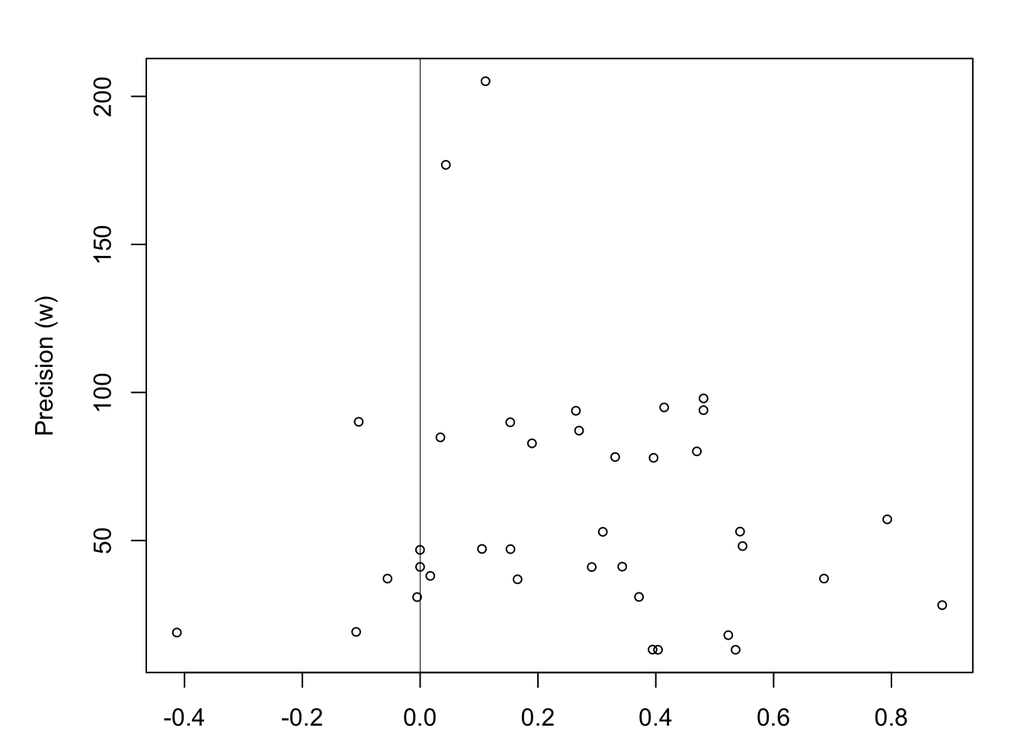

```r
# Plot a funnel plot to view the distribution of the effect sizes by their
# precision (only for initial checking, not used in any analysis)
par(mfcol = c(1, 1), mar = c(2, 4, 2, 1.75), oma = c(0, 1, 0, 0))
plot(jitter(data$Zr), jitter(data$w), cex = 0.75, xlab = "", ylab = "Precision (w)")
abline(v = 0, lwd = 0.5)
```

```r
# Create table that counts the total number of each random factor. This can
# be adapted for any random factors. Note that in this example, we are using
# the 'unique' function to count the number of unique studies and species to
# avoid double counting.

get.table <- function(x) {
    stuff <- c(paste("N_studies = ", length(unique(x$Paper))), paste("N_faceSamples = ",
        length(unique(x$FaceSample))), paste("N_participantSamples = ", length(unique(x$ParticipantSample))),
        paste("N_ES = ", length(x$Zr)))
}

kable(get.table(data), "html") %>% kable_styling("striped", position = "left")
```

| x |
| --- |
| N_studies = 13 |
| N_faceSamples = 17 |
| N_participantSamples = 33 |
| N_ES = 37 |

```r
# simple tables for counting the number of levels of each factor if level
# with smallest number of cases has less than 10% of highest, then can't
# compare

# min = 1, max = 17: a problem, but will include for theoretical reasons and
# check with 'Honesty' removed
levels(data$OverallDomain)
```

```
## [1] "Aggressiveness" "Agreeableness"  "Criminal"       "Economic"
## [5] "Honesty"        "Sexual"
```

```r
table(data$OverallDomain)
```

```
##
## Aggressiveness  Agreeableness       Criminal       Economic        Honesty
##              6              7              4             17              1
##         Sexual
##              2
```

```r
# min 9, max 28: fine
levels(data$RespMethRecode)
```

```
## [1] "Explicit"      "MoneyTransfer"
```

```r
table(data$RespMethRecode)
```

```
##
##      Explicit MoneyTransfer
##            28             9
```

```r
# min 9, max 28: fine
levels(data$GTOpRecode)
```

```
## [1] "Behavioural "      "Self/other report"
```

```r
table(data$GTOpRecode)
```

```
##
##      Behavioural  Self/other report
##                28                 9
```

```r
# min = 6, max = 31: fine
levels(data$PhotoTypeRecode)
```

```
## [1] "computer" "original"
```

```r
table(data$PhotoTypeRecode)
```

```
##
## computer original
##        6       31
```

```r
# min = 2, max = 35: don't use
levels(data$Point_of_Decision)
```

```
## [1] "No"  "Yes"
```

```r
table(data$Point_of_Decision)
```

```
##
##  No Yes
##  35   2
```

```r
# min = 1, max = 33: don't use
levels(data$PhotoSource)
```

```
## [1] "lab"     "media"   "mugshot"
```

```r
table(data$PhotoSource)
```

```
##
##     lab   media mugshot
##      33       3       1
```

```r
# so our moderators moving forward are RespMethRecode, GTOpRecode,
# PhotoTypeRecode and Domain

# cross-tables to check whether there is any dependence between factors

table(data$RespMethRecode, data$GTOpRecode)
```

```
##
##                 Behavioural  Self/other report
##   Explicit                19                 9
##   MoneyTransfer            9                 0
```

```r
table(data$RespMethRecode, data$PhotoTypeRecode)
```

```
##
##                 computer original
##   Explicit             6       22
##   MoneyTransfer        0        9
```

```r
table(data$RespMethRecode, data$OverallDomain)
```

```
##
##                 Aggressiveness Agreeableness Criminal Economic Honesty
##   Explicit                   6             7        4        8       1
##   MoneyTransfer              0             0        0        9       0
##
##                 Sexual
##   Explicit           2
##   MoneyTransfer      0
```

```r
table(data$GTOpRecode, data$PhotoTypeRecode)
```

```
##
##                     computer original
##   Behavioural              0       28
##   Self/other report        6        3
```

```r
table(data$GTOpRecode, data$OverallDomain)
```

```
##
##                     Aggressiveness Agreeableness Criminal Economic Honesty
##   Behavioural                    6             0        4       17       1
##   Self/other report              0             7        0        0       0
##
##                     Sexual
##   Behavioural            0
##   Self/other report      2
```

```r
table(data$PhotoTypeRecode, data$OverallDomain)
```

```
##
##            Aggressiveness Agreeableness Criminal Economic Honesty Sexual
##   computer              0             6        0        0       0      0
##   original              6             1        4       17       1      2
```

## Meta-analysis

### Here, we are testing whether we need to include the random factors in our meta-analysis models. We will be running likelihood ratio tests to compare models that include the random factors to the intercept-only model. We do this step by step - 1. Test each random factor separately. 2. Include the significant random factors together to see if they improve the model further. Some random factors take theoretical precedance over others. For example, Studyid is usually an important random factor.

### The important stats here for the model comparison is the loglik values.

### Throughout the analysis that we swtich between REML and ML in the specification of the method for the RMA models. We run REML when we want to extract parameter estimates. We run ML when we want to compare models.

```r
# M0: model without random-effects using rma () to calculate I2
# (heterogeneity) vi = precision
res0 <- rma(yi = Zr, vi = 1/w, data = data, method = "REML")  #I^2 = 71.84%
summary(res0)
```

```
##
## Random-Effects Model (k = 37; tau^2 estimator: REML)
##
##   logLik  deviance       AIC       BIC      AICc
##  -3.1053    6.2107   10.2107   13.3777   10.5743
##
## tau^2 (estimated amount of total heterogeneity): 0.0426 (SE = 0.0149)
## tau (square root of estimated tau^2 value):      0.2065
## I^2 (total heterogeneity / total variability):   71.84%
## H^2 (total variability / sampling variability):  3.55
##
## Test for Heterogeneity:
## Q(df = 36) = 120.3109, p-val < .0001
##
## Model Results:
##
## estimate      se    zval    pval   ci.lb   ci.ub
##   0.2682  0.0418  6.4235  <.0001  0.1864  0.3501  ***
##
## ---
## Signif. codes:  0 '***' 0.001 '**' 0.01 '*' 0.05 '.' 0.1 ' ' 1
```

```r
# save model object for plotting purposes save(res0, 'M0_I2_Rater.RData')

# M1: model without random-effects intercept-only model)
res1 <- rma.mv(yi = Zr, V = 1/w, data = data, method = "ML")
summary(res1)
```

```
##
## Multivariate Meta-Analysis Model (k = 37; method: ML)
##
##   logLik  Deviance       AIC       BIC      AICc
## -22.2373  120.3109   46.4747   48.0856   46.5890
##
## Variance Components: none
##
## Test for Heterogeneity:
## Q(df = 36) = 120.3109, p-val < .0001
##
## Model Results:
##
## estimate      se     zval    pval   ci.lb   ci.ub
##   0.2523  0.0211  11.9476  <.0001  0.2109  0.2937  ***
##
## ---
## Signif. codes:  0 '***' 0.001 '**' 0.01 '*' 0.05 '.' 0.1 ' ' 1
```

```r
llres1 <- fitstats(res1)[1]

# M2: random-effect model(intercept-only model) with Paper
res2 <- rma.mv(yi = Zr, V = 1/w, random = list(~1 | Paper), data = data, method = "ML")
summary(res2)
```

```
##
## Multivariate Meta-Analysis Model (k = 37; method: ML)
##
##   logLik  Deviance       AIC       BIC      AICc
##  -7.2248   90.2858   18.4496   21.6714   18.8025
##
## Variance Components:
##
##             estim    sqrt  nlvls  fixed  factor
## sigma^2    0.0438  0.2094     13     no   Paper
##
## Test for Heterogeneity:
## Q(df = 36) = 120.3109, p-val < .0001
##
## Model Results:
##
## estimate      se    zval    pval   ci.lb   ci.ub
##   0.2776  0.0647  4.2903  <.0001  0.1508  0.4045  ***
##
## ---
## Signif. codes:  0 '***' 0.001 '**' 0.01 '*' 0.05 '.' 0.1 ' ' 1
```

```r
llres2 <- fitstats(res2)[1]

# adding effect size level random effect

obs <- 1:dim(data)[1]

res2b <- rma.mv(yi = Zr, V = 1/w, random = list(~1 | Paper, ~1 | obs), data = data,
    method = "REML")
summary(res2b)
```

```
##
## Multivariate Meta-Analysis Model (k = 37; method: REML)
##
##   logLik  Deviance       AIC       BIC      AICc
##  -1.6039    3.2078    9.2078   13.9583    9.9578
##
## Variance Components:
##
##             estim    sqrt  nlvls  fixed  factor
## sigma^2.1  0.0325  0.1802     13     no   Paper
## sigma^2.2  0.0224  0.1496     37     no     obs
##
## Test for Heterogeneity:
## Q(df = 36) = 120.3109, p-val < .0001
##
## Model Results:
##
## estimate      se    zval    pval   ci.lb   ci.ub
##   0.2720  0.0634  4.2915  <.0001  0.1478  0.3963  ***
##
## ---
## Signif. codes:  0 '***' 0.001 '**' 0.01 '*' 0.05 '.' 0.1 ' ' 1
```

```r
i2_ml(res2b)
```

```
##  I2_total  I2_Paper    I2_obs
## 0.7665221 0.4538464 0.3126757
```

```r
# seems like more heterogeneity once you put obs

# one can do likehood ratio test

anova(res1, res2)
```

```
##         df     AIC     BIC    AICc   logLik     LRT   pval       QE
## Full     2 18.4496 21.6714 18.8025  -7.2248                120.3109
## Reduced  1 46.4747 48.0856 46.5890 -22.2373 30.0251 <.0001 120.3109
```

```r
# Likelihood ratio test to test the effect of Paper
(2 * abs(llres1)) - (2 * abs(llres2))
```

```
## [1] 30.0251
```

```r
pchisq(((2 * abs(llres1)) - (2 * abs(llres2))), 1, lower.tail = FALSE)
```

```
## [1] 4.264909e-08
```

```r
# significant improvement

# M3: random-effect model(intercept-only model) with FaceSample
res3 <- rma.mv(yi = Zr, V = 1/w, random = list(~1 | FaceSample), data = data,
    method = "ML")
summary(res3)
```

```
##
## Multivariate Meta-Analysis Model (k = 37; method: ML)
##
##   logLik  Deviance       AIC       BIC      AICc
##  -2.9913   81.8188    9.9826   13.2044   10.3355
##
## Variance Components:
##
##             estim    sqrt  nlvls  fixed      factor
## sigma^2    0.0431  0.2075     17     no  FaceSample
##
## Test for Heterogeneity:
## Q(df = 36) = 120.3109, p-val < .0001
##
## Model Results:
##
## estimate      se    zval    pval   ci.lb   ci.ub
##   0.2272  0.0588  3.8670  0.0001  0.1120  0.3423  ***
##
## ---
## Signif. codes:  0 '***' 0.001 '**' 0.01 '*' 0.05 '.' 0.1 ' ' 1
```

```r
llres3 <- fitstats(res3)[1]

# obs in
res3b <- rma.mv(yi = Zr, V = 1/w, random = list(~1 | FaceSample, ~1 | obs),
    data = data, method = "REML")
summary(res3b)
```

```
##
## Multivariate Meta-Analysis Model (k = 37; method: REML)
##
##   logLik  Deviance       AIC       BIC      AICc
##   0.5966   -1.1932    4.8068    9.5573    5.5568
##
## Variance Components:
##
##             estim    sqrt  nlvls  fixed      factor
## sigma^2.1  0.0392  0.1980     17     no  FaceSample
## sigma^2.2  0.0139  0.1180     37     no         obs
##
## Test for Heterogeneity:
## Q(df = 36) = 120.3109, p-val < .0001
##
## Model Results:
##
## estimate      se    zval    pval   ci.lb   ci.ub
##   0.2321  0.0611  3.7971  0.0001  0.1123  0.3519  ***
##
## ---
## Signif. codes:  0 '***' 0.001 '**' 0.01 '*' 0.05 '.' 0.1 ' ' 1
```

```r
i2_ml(res3b)
```

```
##      I2_total I2_FaceSample        I2_obs
##     0.7607289     0.5614026     0.1993263
```

```r
# I2 mostly due to FaceSample

# Likelihood ratio test to test the effect of FaceSample
(2 * abs(llres1)) - (2 * abs(llres3))
```

```
## [1] 38.49211
```

```r
pchisq(((2 * abs(llres1)) - (2 * abs(llres3))), 1, lower.tail = FALSE)
```

```
## [1] 5.497556e-10
```